# Reproducible Research: Peer Assessment 1

The following analysis was performed on 20 September, 2015.

A discussion of the dataset and objectives can be found [here in GitHub](https://github.com/fsmithus/RepData_PeerAssessment1).

## Loading and preprocessing the data

Set the working directory (any empty folder will do), and load environment as required.

```r
setwd("~/Documents/Academic/DataScience/Reproduceable_Research/RepData_PeerAssessment1/")
library(lattice)
```

### Questions 1 & 2 - Fetch and load the data.

Download, unzip, and read the activity/step data. No pre-processing is required for this analysis.

```r
download.file("http://d396qusza40orc.cloudfront.net/repdata%2Fdata%2Factivity.zip","repdata_data_activity.zip")
unzip("repdata_data_activity.zip")
data <- read.csv("activity.csv")
```

## What is mean total number of steps taken per day?

### Question 1 - Plot histogram of the number of steps per day.

First calculate and plot the total steps for each day.

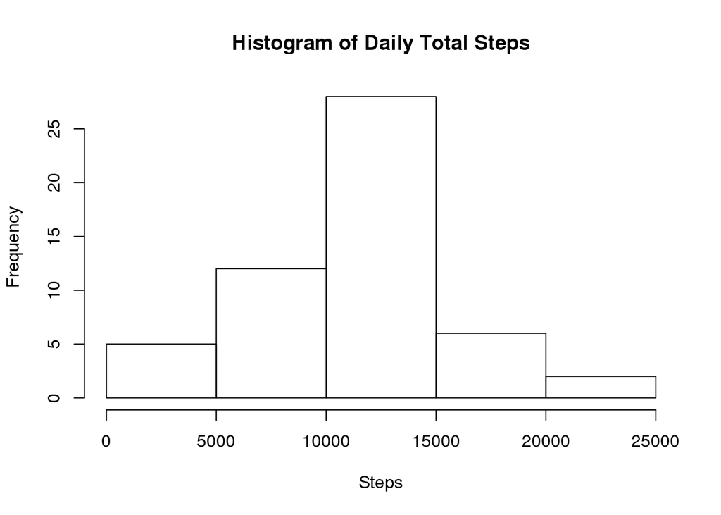

```r
daily.total <- aggregate(list(steps = data$steps),
                         list(date = cut.Date(as.Date(data$date),breaks="day")),sum)
hist(daily.total$steps,xlab="Steps",main="Histogram of Daily Total Steps")
```

### Question 2 - Calculate the mean and median number of steps per day.

Compute the mean steps per day. Ignore missing values.

```r
mean(daily.total$steps,na.rm=TRUE)
```

```
## [1] 10766.19
```

Compute the median steps per day. Ignore missing values.

```r
median(daily.total$steps,na.rm=TRUE)
```

```
## [1] 10765
```

## What is the average daily activity pattern?

### Question 1 - Plot average steps per interval across all days.

Calculate the average steps for each interval across days. Ignore missing values.

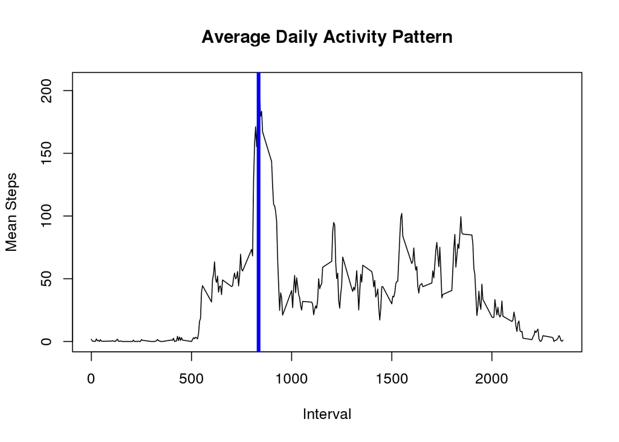

```r
interval.mean <- aggregate(list(steps = data$steps),list(interval = data$interval),mean,na.rm=TRUE)
max.interval <- which.max(interval.mean$steps)
plot(interval.mean$interval,interval.mean$steps,type="l",
     xlab="Interval",ylab="Mean Steps",main="Average Daily Activity Pattern")
abline(v=interval.mean[max.interval,1],col="blue",lwd=4)
```

### Question 2 - Which interval contains maximum average number of steps?

Calculate the interval (time-of-day) with the maximum average number of steps.

```r
interval.mean[max.interval,"interval"]
```

```
## [1] 835
```

## Imputing missing values

### Question 1 - Calculate the total number of missing step values in the dataset.

```r
sum(is.na(data$steps))
```

```
## [1] 2304
```

### Question 2 - Define a strategy to fill-in the missing values.

My strategy is to use the interval mean for each missing interval in a given day.

### Question 3 - Create new dataset.

Copy the original data, then fill in missing values with interval means.

```r
data.imputed <- data
for (i in 1:nrow(data.imputed)) {
        if (is.na(data.imputed[i,"steps"])) {
                interval <- data.imputed[i,"interval"]
                data.imputed[i,"steps"] <- interval.mean[interval.mean$interval==interval,"steps"]
        }
}
```

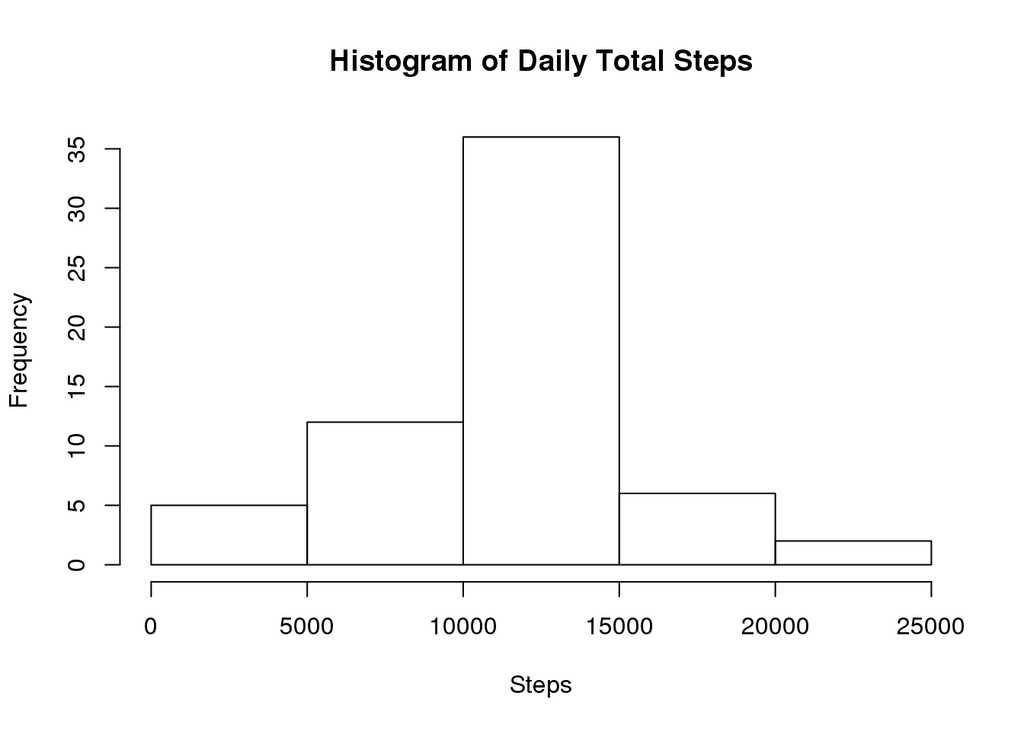

```r
daily.imputed.total <- aggregate(list(steps = data.imputed$steps),
                                 list(date = cut.Date(as.Date(data.imputed$date),breaks="day")),sum)
hist(daily.imputed.total$steps,xlab="Steps",main="Histogram of Daily Total Steps")
```

Compute the mean steps per day. Ignore missing values.

```r
mean(daily.imputed.total$steps,na.rm=TRUE)
```

```
## [1] 10766.19
```

Compute the median steps per day. Ignore missing values.

```r
median(daily.imputed.total$steps,na.rm=TRUE)
```

```
## [1] 10766.19
```

## Are there differences in activity patterns between weekdays and weekends?

Continuing with the imputed dataset…

### Question 1 - Add a column to categorize each observation as “weekday” or “weekend”.

Translate dates to factors.

```r
w <- weekdays(as.Date(data.imputed$date)) %in% c("Saturday","Sunday")
x <- rep("",length(w))
for (i in 1:length(w)) {
        if (w[i])       {x[i] <- "weekend"}
        else            {x[i] <- "weekday"}
}
data.imputed$day.type <- as.factor(x)
```

### Question 2 - Make a panel plot comparing weekday and weekend activity.

Plot weekday/weekend comparison using the lattice package.

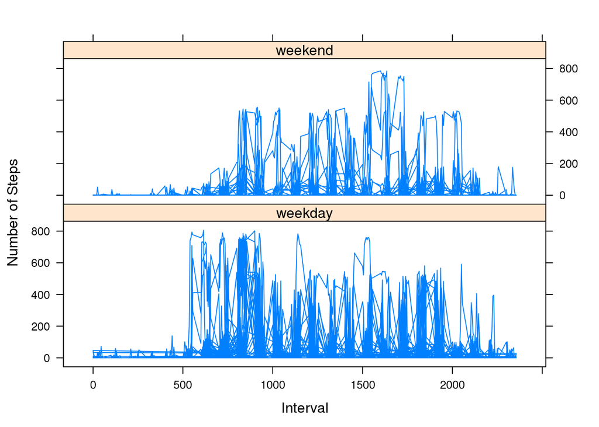

```r
xyplot(data.imputed$steps ~ data.imputed$interval | data.imputed$day.type,
       layout=c(1,2), type="l",xlab="Interval",ylab="Number of Steps")
```

With a little more effort, I could reduce the noise in the plots, but it appears that weekdays see the most steps around 8:00am and again around 6:00pm. Weekend days appear to have fewer steps with the peak around 4:00pm.

(Out of time.)